# PrepCourse_R_Lab2

Jing Xu

Applied Bioinformatics, B330, DKFZ

jing.xu@dkfz.de

16 Mai, 2019

# 1 R Assignment2

This is a “R Markdown” file of assignment in R. You need to follow the instructions and write down some answers to the questions. Carefully read through the whole document, once you answer all the questions, you can `knit` the file in order to get the output html file. It is required that you send the html page to **Jing Xu** at jing.xu@dkfz.de no later than **March 15,2019** to get your credit points for the course.

## 1.1 Objectives

In this assignment, you need to

```
* search R functions on your own
* check help page of R functions
* do simple statisitics with R
```

## 1.2 Contact

In case you have any questions, or further interests in doing internships and degree projects, you are always welcome to contact your tutors in the Applied Bioinformatics group (Prof. Benedikt Brors, B330, DKFZ).

# 2 $\color{blue}{\text{Have fun with R now!}}$

# 3 Create R objects

1. Create a numeric vector of ‘113355’ and repeat the series for 4 times, but **ONLY** show the first 8 numbers of the series. Store your final result in a variable called **y**. You can do this in separate steps or in one step. Try both ways!  
   **Hint:** Look up the help page of the function.

```r
# write your answers here!
## in separate steps
x <- rep(c(1,3,5), each=2)
y <- rep(x, times=4)
y <- y[1:8];y
```

```
## [1] 1 1 3 3 5 5 1 1
```

```r
## in one step
y <- rep(c(1,3,5), each=2, times=4, len=8);y
```

```
## [1] 1 1 3 3 5 5 1 1
```

2. Extract even numbers from a numeric vector **x** defined for you.  
   **Hint:** We didn’t mention this in the lecture, you need to think what kind of feature do even numbers have (or odd numbers do not have)?

```r
x <- seq(1,50)
# write your answers here!
x[x %% 2 == 0]
```

```
##  [1]  2  4  6  8 10 12 14 16 18 20 22 24 26 28 30 32 34 36 38 40 42 44 46 48
## [25] 50
```

3. Simple lottery  
   Write an R script to select a winning lotto number. We need to pick 5 lotto jackpots from a total of 50 jackpots, each ball has an unique number on it (numbers range from 1 to 50). Output the winning number in a variable called **winner**.  
   **Hint**: you may find out that the numbers can be different every time from random sampling, but we can only have one winner! How to solve this problem?

```r
pool <- seq(1,50)
set.seed(123)
winner = sample(pool,5, replace = F)
winner
```

```
## [1] 15 39 20 42 44
```

# 4 Descriptive statistics

1. Two dice game  
   Two dice game is the one of the oldest game in the gambling, you need to bet on the number of the sum of two 6-sided dices. In order to make the best guess, we need to find out the distribution of the sum,
- show it in a histogram (density plot)
- find out the most and the second frequently appeared numbers

It’s a bit complicated if we calculate it manually, but R can help you with that! Write your own R code!  
**Hint**: You may need to get all possible combination of numbers first. If you use random sampling, how many times do you need to roll the dices to get a good approximation?

## 4.1 method1: get all possible combination

Did you notice? When you throw two dices, the sum of two dices do not occur randomly, there is a distribution.

```r
# write your answers here!
Dice = c(1:6,1:6)
# Get all combinations of 2 elements in matrix
combs <- combn(Dice, 2)

# Find the resulting sums
all_sum <- colSums(combs)
sort(table(all_sum), decreasing = T)
```

```
## all_sum
##  7  6  8  5  9  4 10  3 11  2 12
## 12  9  9  8  8  5  5  4  4  1  1
```

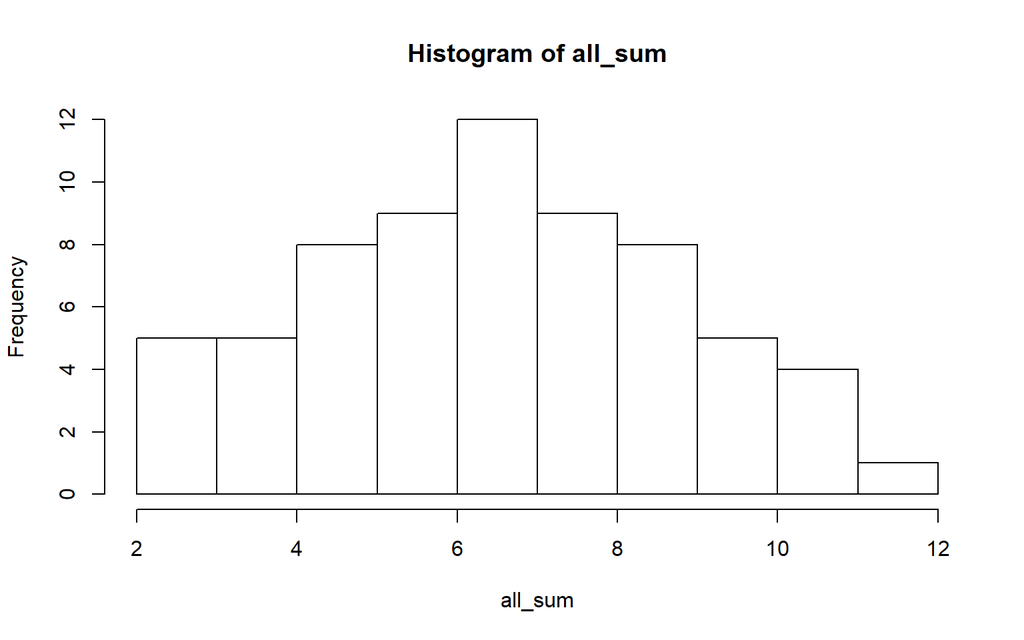

```r
# draw a histogram
hist(all_sum)
```

```r
# pick the most and the second frequently appeared numbers
names(sort(table(all_sum), decreasing = T)[1])
```

```
## [1] "7"
```

```r
# since 6 and 8 share the same frequency, we output them together
names(sort(table(all_sum), decreasing = T)[2:3])
```

```
## [1] "6" "8"
```

## 4.2 method2: random sampling test by different resampling times

Since random sampling gives you different numbers every time, you need to have sufficient resampling times to ensure this methods output a more or less correct answer, which means to get a normal distribution. Of course if you sample a huge number of times, you will get the correct answer, but it’s better to reduce the number of calculations.

We can use **Shapiro-Wilk Normality Test** for testing. This is a very important test for you to know. Too many people use t-test in all kinds of statistics, which is not correct! T-test can only be applied when you have data in normal distribution, one should always test this before calculation. P value < 0.1 is appropriate to be called as normal distribution.

We don’t want you to calculate complex mathematical equations. You just need to try to sample different times and run your code for a few times until you always get p <0.1. How about 50 times?

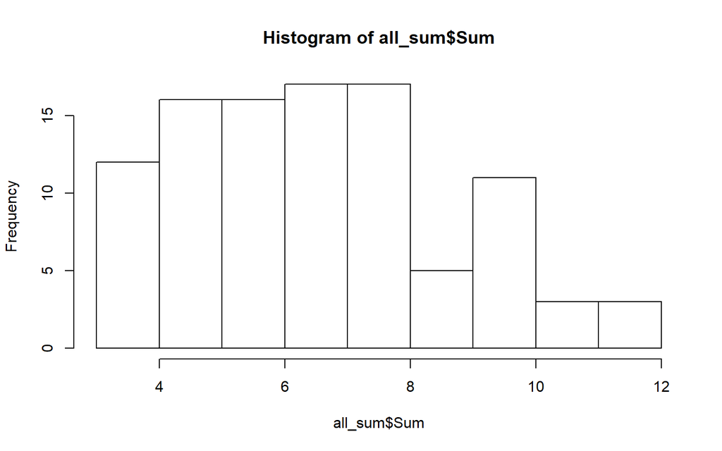

```r
Dice1 = sample(1:6, 100, replace = TRUE)
Dice2 = sample(1:6, 100, replace = TRUE)
all_sum = data.frame(Dice1=Dice1, Dice2=Dice2, Sum = Dice1 + Dice2)

# draw a histogram
hist(all_sum$Sum)
```

```r
# test normality by Shapiro-Wilk Normality Test
if (shapiro.test(all_sum$Sum)$p.value < 0.1) {
    # pick the most and the second frequently appeared numbers
    print(names(sort(table(all_sum$Sum), decreasing = T)[1]))
    print(names(sort(table(all_sum$Sum), decreasing = T)[2]))
} else {
    print("You didn't sample enough times!")
}
```

```
## [1] "7"
## [1] "8"
```

# 5 Solve sequencing-related problem

Now you have learned bash, python and R, how to solve step2 from Day1 with R? * Extract rows of **the first 100 lines** including the comment lines and save it in a txt file in your working directory with bash. You may try to use the Terminal with bash in Rstudio (but not required), in case you want to try to use it with Windows system, you need to go to store to install Linux system for Windows.  
* Read in this file into R * As you already know, this file has 9 columns but has no column names, add the following column names: “chr_name”, “annotation_source”, “feature_type”, “START”, “END”, “score”, “strand”, “genomic_phase_CDS”, “INFO” * Solve problems in step2 and anwswer additional questions

**Hint**: 1. You may need to work with list, check `sapply` function 2. You may try `dplyr` package

- Q1. What kinds of “feature types” exist in this file?

```r
# write your answers here!
Anno <- read.csv("D:/Teaching/PrepCourseBioinformatics2019/R_lab2/Genecode.txt", header = F, sep="\t", stringsAsFactors = F, skip=5)

# show number of rows
nrow(Anno)
```

```
## [1] 95
```

```r
# Add column names
colnames(Anno) <- c("chromosome", "annotation_source", "feature_type", "START", "END", "score",
                    "strand", "genomic_phase_CDS", "INFO")

unique(Anno$feature_type)
```

```
## [1] "transcript" "exon"       "gene"
```

- Q2. How many kinds of “+” and “-” strands are there in this file?

```r
# write your answers here!
table(Anno$strand)
```

```
##
##  -  +
## 69 26
```

- Q3. Solve problems in step2 from Day1 with R and output the head and tail of the final table

```r
# write your answers here!
## separate first with semicolon
gene_id <- sapply(strsplit(Anno[,9], ";"), `[[`, 1) # stringr::str_split function works the same
gene_name <- sapply(strsplit(Anno[,9], ";"), `[[`, 5)# stringr::str_split function works the same

## 2nd separation with space
## method1 Use str_sub function from stringr package
gene_id <- str_sub(gene_id, 9,-1); gene_name <- str_sub(gene_name, 13,-1)

BED <- Anno %>% select(chromosome, strand, START,END)
BED$INFO <- paste(gene_name,"_",gene_id, sep="")

# convert coordinates, gtf file is 1-based, and BED file is 0-based
## method1. use ifelse
BED$promoterSTART = ifelse(BED$strand =="+", BED$START - 501, BED$START + 499)
BED$promoterEND = ifelse(BED$END =="-", BED$END + 99, BED$END -101)

BED = BED %>% select(chromosome, promoterSTART, promoterEND,INFO)
```

```r
## 2nd separation with space
## method2
gene_id <- substr(gene_id, 9,nchar(gene_id)); gene_name <- substr(gene_name, 13,nchar(gene_name))
# method3
gene_id <- gsub('[A-z ]* ', '' , gene_id); gene_name <- gsub('[A-z ]* ', '' , gene_name)
# method4
gene_id <- sub(".* ", "", gene_id); gene_name <-  sub(".* ", "", gene_name)

## convert coordinates
## method2. without using addtional package
BED[BED$strand=="+", "START"] <- BED[BED$strand=="+", "START"] - 501
BED[BED$END=="+", "END" ] <- BED[BED$END=="-", "END" ] + 99

BED[BED$strand=="-", "START"] <- BED[BED$strand=="+", "START"] + 499
BED[BED$END=="-", "END" ] <- BED[BED$END=="-", "END" ] -101
```

Give head of your final table

```r
head(BED)
```

```
##   chromosome promoterSTART promoterEND                     INFO
## 1       chr1         11371       14311 DX11L1_ENSG00000223972.4
## 2       chr1         11371       12126 DX11L1_ENSG00000223972.4
## 3       chr1         12112       12620 DX11L1_ENSG00000223972.4
## 4       chr1         12724       14311 DX11L1_ENSG00000223972.4
## 5       chr1         11373       14308 DX11L1_ENSG00000223972.4
## 6       chr1         11373       12126 DX11L1_ENSG00000223972.4
```

Give tail of your final table

```r
tail(BED)
```

```
##    chromosome promoterSTART promoterEND                     INFO
## 90       chr1         36220       35980 AM138A_ENSG00000237613.2
## 91       chr1         35776       35380 AM138A_ENSG00000237613.2
## 92       chr1         35053       35073 AM138A_ENSG00000237613.2
## 93       chr1         35744       35972 AM138A_ENSG00000237613.2
## 94       chr1         36220       35972 AM138A_ENSG00000237613.2
## 95       chr1         35744       35380 AM138A_ENSG00000237613.2
```

- Q4. Export your data to a desired location
- Export to your final table to current working directory

```r
write.table(BED, "BED_final.txt", sep="\t")
```

- Create a subdirectory under your working directory and export the table there

```r
write.table(BED, "./table/BED_final.txt", sep="\t")
```

In case you want to use python to solve the problems, you can write python code here! But you need to install `reticulate` package first, see descriptions in the setup chunk!

If you decide to you python, remove all characters after “python” to form an executable python code chunk.

# 6 Bonus: exploring heatmaps

This is a bonus question, you don’t need to answer it if you don’t want or you can’t. In case of these situations, just write whatever functional R code in the question code chunk in order to get final output.

Heatmaps are very commonly used in genomics, in this exercise, we’ll build a demo data to create some simple heatmaps. You need to install `RColorBrewer` and `pheatmap` packages first, load them in the setup chunk:

Run the demo chunk in the console to see the demo heatmap

```r
# Generate some data, suppose you did 4 experiments and got the mean values of expression on a number of genes
test = matrix(rnorm(200), 20, 4)
test[1:10, seq(1, 4, 2)] = test[1:10, seq(1, 4, 2)] + 3
test[11:20, seq(2, 4, 2)] = test[11:20, seq(2, 4, 2)] + 2
colnames(test) = paste("Test", 1:4, sep = "")
rownames(test) = paste("Gene", 1:20, sep = "")
head(test)
```

```
##          Test1      Test2    Test3       Test4
## Gene1 4.176220  0.5964251 2.736007 -1.82862663
## Gene2 2.441464  1.8714180 2.247537 -1.81353336
## Gene3 2.054382  0.6028704 3.440692  1.37261371
## Gene4 2.334811 -0.7661688 1.722549 -0.56426954
## Gene5 3.452030 -0.6203265 4.177192  0.97031123
## Gene6 3.526856  0.7901903 3.902506 -0.01863398
```

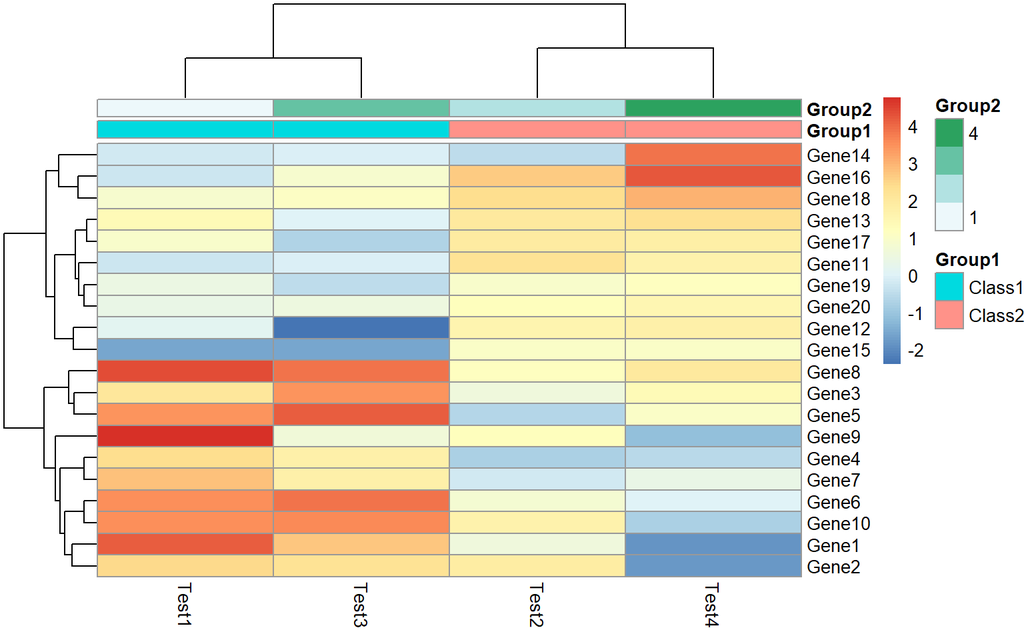

```r
# Generate column annotations, assuming you have two groups:
annotation = data.frame(Group1 = factor(1:4 %% 2 == 0, labels = c("Class1", "Class2"))
                        , Group2 = 1:4)
rownames(annotation) = paste("Test", 1:4, sep = "")

pheatmap(test, annotation = annotation) # auto color
```

If you want to specify colors in the annotation labels (aka. color group1 and 2 in different color sets), what code would you need?

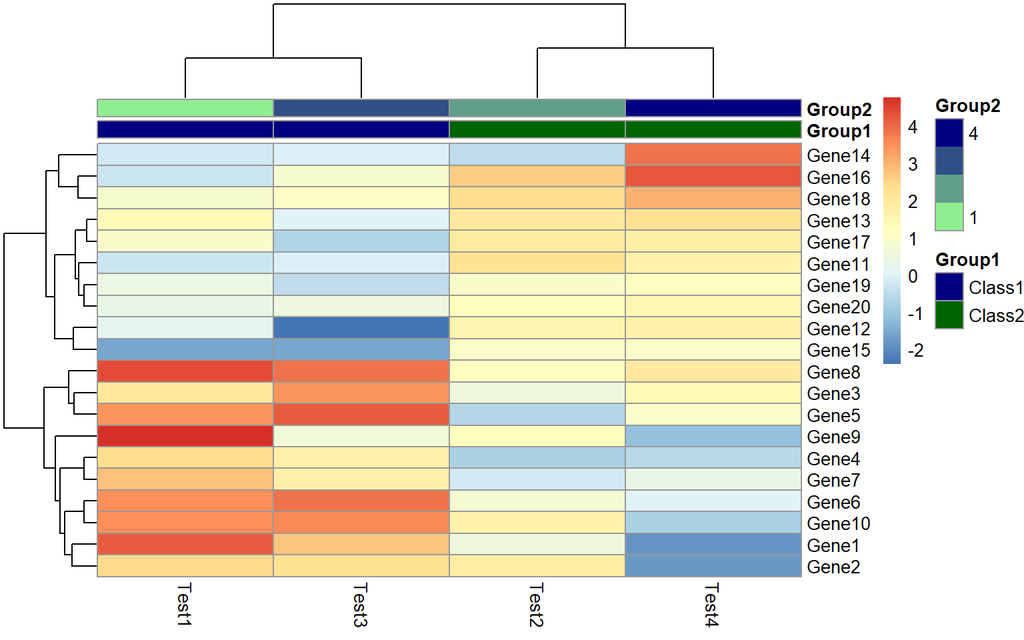

```r
# Specify colors of annotation labels
Group1 = c("navy", "darkgreen")
names(Group1) = c("Class1", "Class2")
Group2 = c("lightgreen", "navy")

ann_colors = list(Group1 = Group1, Group2 = Group2)

pheatmap(test, annotation = annotation, annotation_colors = ann_colors)
```

# 7 Document for reproducibility

It’s always a good practice to output the versions of R and all packages you used for generating the file. Sometimes the script will not work when running with a different R or package version. Reproducibility is highly important in programming as well as in wet labs!

- Which R function is intended to print version information about R? Check `sessionInfo()` function.

This is the last section of the assignment, if you have answered all the questions, you can `knit` this Rmd file now. You won’t be able to do so if there’s any error or unanswered questions left in this file.

You may get some warnings from Rmarkdown compiling, but this is not because your code it wrong. As long as you get the html file, you are good to hand it in.